# Analisis de resultados Rubus glaucus

# Rendimiento estimado anual

A continuación se muestra la tabla correspondiente a la producción acumulada en kg, rendimiento estimado acumulado en t/ha y la cantidad de plantas sembradas estimadas para 1 ha para el año 2021; se puede notar que el mejor rendimiento total fue el de el material Brazos y la mejor producción real acumulada fue para el material Castilla. En conclusión, desde el punto de vista economico, es mas viable producir mora con el material Brazos ya que se pueden sembrar mas plantas por unidad de área comparada con San Antonio y Castilla.

| Genotipo | Producción acum. (kg/parcela) | Rendimiento estimado (t/ha) | Plantas estimadas (pl/ha) |
| --- | --- | --- | --- |
| Brazos | 321.900 | 20.799 | 3424 |
| San Antonio | 239.131 | 14.099 | 3125 |
| Castilla | 377.172 | 13.033 | 1831 |

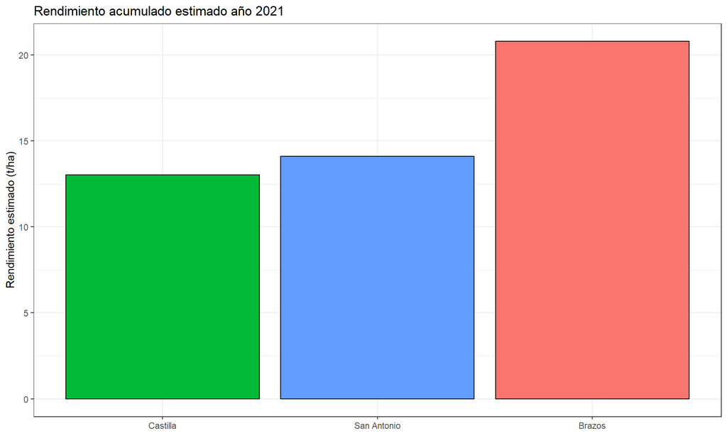

# Analisis de calidad (grados brix)

A continuación se muestran las graficas correspondientes a los datos de grados brix tomados durante el ciclo productivo a los materiales evaluados. Se puede visualizar como varió la acumulación de solidos solubles en cada uno de los materiales evalaluados a traves de tiempo

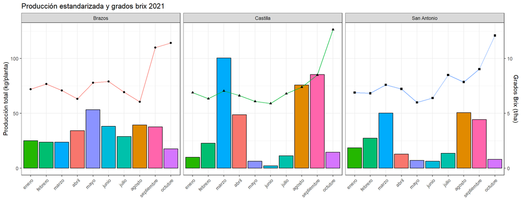

# Analisis de plagas Áfidos

A continuación se muestran las graficas correspondientes al % de incidencia de afidos encontrados en cada uno de los materiales evaluados.

Se puede notar en ambos años de evaluación (2020 y 2021), que el material Brazos mostró muy bajo % de incidencia de afidos, mientras que Castilla y San Antonio mostraron un % de incidencia moderado y alto para los meses de septiembre de 2020 y abril de 2021. Este alto % de incidencia se debe basicamente a que para esos meses no hubo profesional tecnico encargado del cultivo y por lo tanto no fue posible llevar a cabo las diferentes aplicaciones preventivas de insecticida.

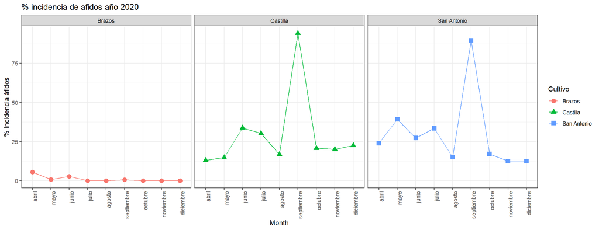

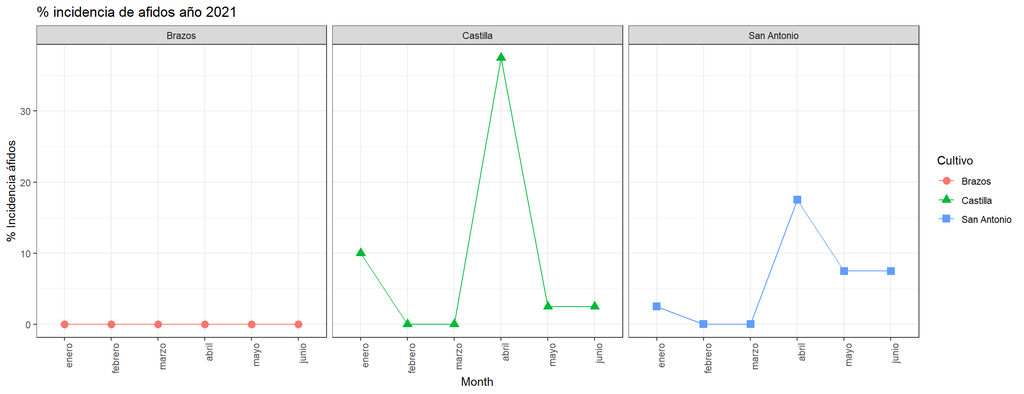

# Analisis de varianza áfidos

A continuación se presenta el analisis de varianza para la plaga Áfidos; se llevo a cabo un modelo estadistico bajo un diseño completamente al azar en donde la variable independiente fueron los materiales evaluados y la varriable dependiente fué la incidencia de los áfidos.

|  | Df | Sum Sq | Mean Sq | F value | Pr(>F) |
| --- | --- | --- | --- | --- | --- |
| Cultivo | 2 | 4075.725 | 2037.8625 | 5.788834 | 0.006019705 |
| Residuals | 42 | 14785.400 | 352.0333 | NA | NA |

La tabla previa muestra que hubo un efecto estadistico significativo en la incidencia de los áfidos sobre los materiales evaluados. A continuación se muestra la el resultado del agrupamiento de Tukey.

Se llevó a cabo una prueba post Anova basada en el agrupamiento del criterio de Tukey; en la cual se encontró que Brazos fue el material que menor incidencia tuvo, seguido de San Antonio con 20.383 % y finalmente Castilla sin espinas con 21.233 %. El material Brazos fue el unico diferentes en terminos estadisticos, ya que su agrupamiento fue con la letra “a”, mientras que San Antonio y Castilla se agruparon bajo la letra “b”, es decir, estos dos ultimos materiales resultaron ser estadisticamente iguales.

|  | Cultivo | emmean | SE | df | lower.CL | upper.CL | .group |
| --- | --- | --- | --- | --- | --- | --- | --- |
| 1 | Brazos | 0.6333333 | 4.84447 | 42 | -9.143203 | 10.40987 | a |
| 3 | San Antonio | 20.3833333 | 4.84447 | 42 | 10.606797 | 30.15987 | b |
| 2 | Castilla | 21.2333333 | 4.84447 | 42 | 11.456797 | 31.00987 | b |

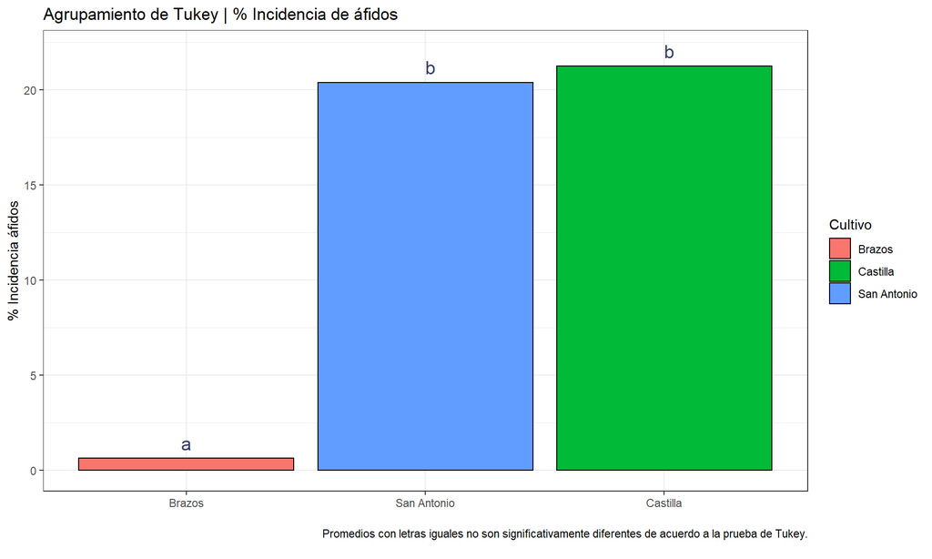

# Oidium

Se pudo notar que el porcentaje de incidencia y severidad de *Oidium* para ambos años de evaluación (2020 y 2021), tuvieron un efecto significativo en los materiales Castilla y San Antonio; el material Brazos mostró una alta tolerancia durante los dos años de evaluación.

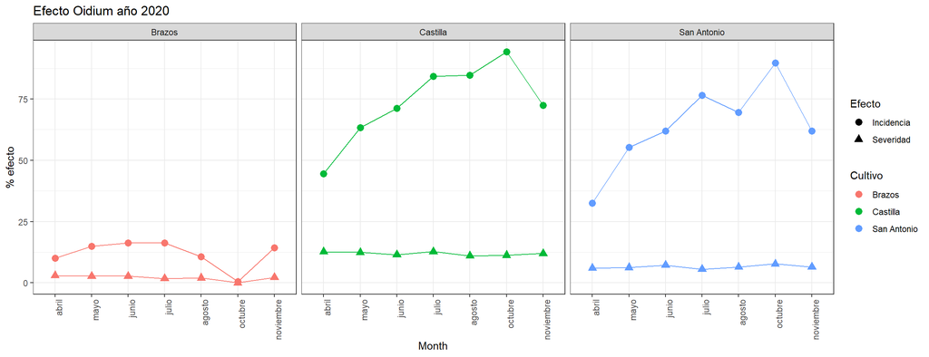

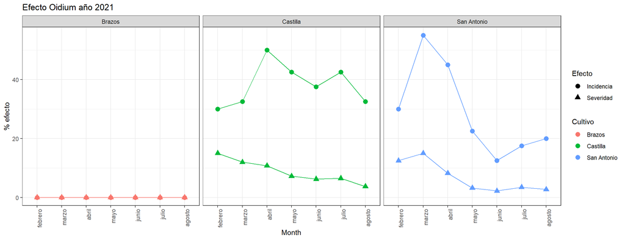

# Analisis de varianza para % de Incidencia de Oidium

|  | Df | Sum Sq | Mean Sq | F value | Pr(>F) |
| --- | --- | --- | --- | --- | --- |
| Cultivo | 2 | 19712.61 | 9856.3051 | 26.22999 | 6.049979e-08 |
| Residuals | 39 | 14654.83 | 375.7648 | NA | NA |

|  | Cultivo | emmean | SE | df | lower.CL | upper.CL | .group |
| --- | --- | --- | --- | --- | --- | --- | --- |
| 1 | Brazos | 5.928571 | 5.180766 | 39 | -4.550518 | 16.40766 | a |
| 3 | San Antonio | 46.428571 | 5.180766 | 39 | 35.949482 | 56.90766 | b |
| 2 | Castilla | 55.875000 | 5.180766 | 39 | 45.395911 | 66.35409 | b |

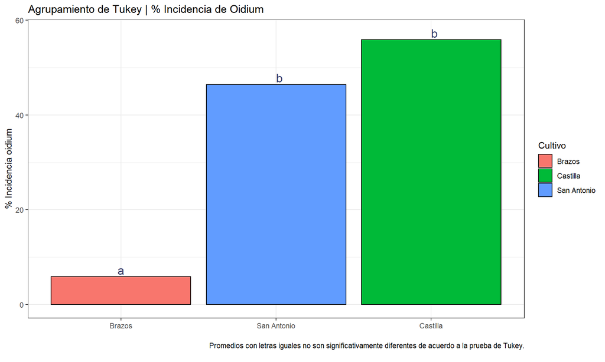